# Modèles de survie en R – Correction

- Show All Code
- Hide All Code
- View Source

Années universitaires 2025–2026 et 2026–2027 • Parcours Économie de la santé & Développement durable

Durée de grèves et cycle économique

Author

Pierre Beaucoral

```r
knitr::opts_chunk$set(fig.width = 7, fig.height = 4, fig.align = "center")

library(survival)
library(AER)      # StrikeDuration
library(dplyr)
library(ggplot2)

if (requireNamespace("survminer", quietly = TRUE)) {
  library(survminer)
}

# Données brutes de grève
data("StrikeDuration")
strikes_raw <- StrikeDuration

# Construction d'un jeu de données pour le TD
# - censure artificielle à 200 jours
# - 2 versions catégorielles du choc d'activité
strikes <- strikes_raw |>
  mutate(
    # variable de durée
    time   = pmin(duration, 200),
    status = ifelse(duration > 200, 0, 1),  # 1 = fin de grève observée au plus tard au jour 200, 0 = censuré à 200

    # choc d'activité non anticipé (déjà continu) :
    #   uoutput > 0 -> cycle favorable ; < 0 -> cycle défavorable
    uoutput_sign = case_when(
      uoutput < 0  ~ "Cycle défavorable",
      uoutput == 0 ~ "Cycle neutre",
      uoutput > 0  ~ "Cycle favorable"
    ),

    # version en 3 classes par terciles (plutôt pour les KM)
    # NB : uoutput ne prend que 9 valeurs distinctes, d'où des classes
    # d'effectifs inégaux (25 / 17 / 20) ; on garde ces seuils tels quels
    uoutput_q = cut(
      uoutput,
      breaks = quantile(uoutput, probs = c(0, .33, .66, 1), na.rm = TRUE),
      labels = c("Choc faible", "Choc moyen", "Choc fort"),
      include.lowest = TRUE
    )
  )

# Objet de survie pour les grèves (avec censure artificielle à 200 jours)
S_strikes <- Surv(time = strikes$time, event = strikes$status)

# Modèle de Cox simple sur uoutput (= modèle M1 des questions 8 à 11)
cox_uoutput <- coxph(S_strikes ~ uoutput, data = strikes)

# Mise en forme des nombres cités dans le texte (virgule décimale)
fmt <- function(x, d = 2) {
  formatC(as.numeric(x), format = "f", digits = d,
          decimal.mark = ",", big.mark = " ")
}
fp <- function(p) ifelse(p < 0.001, "< 0,001", fmt(p, 3))
```

# 1 Notions de base & censure

## 1.1 Données de durée de vie

On s’intéresse à une **durée aléatoire** $T$ (positive) :

- durée d’une grève
- durée d’un épisode de chômage
- durée de séjour à l’hôpital
- durée jusqu’à un défaut de paiement, etc.

Pour chaque unité (grève, individu, contrat) $i = 1,\dots,n$ :

- $T_i$ : **durée vraie** (inobservable en général)
- on observe seulement :
  - $t_i$ : **durée observée**
  - $\delta_i$ : **indicatrice d’événement**

avec :

- $\delta_i = 1$ si l’événement est observé (fin de grève pendant l’observation)
- $\delta_i = 0$ si la durée est **censurée** (on sait juste que la grève dure au moins jusqu’à $t_i$)

## 1.2 Encodage en R

En R, on encode le couple $(t_i, \delta_i)$ avec la fonction `Surv()` du package **survival**.

```r
# Exemple jouet : 5 durées, 2 censures
t  <- c(3, 5, 8, 10, 4)         # durées observées
d  <- c(1, 0, 1, 0, 1)          # 1 = événement, 0 = censuré

S_ex <- Surv(time = t, event = d)
S_ex
```

```
[1]  3   5+  8  10+  4
```

- Les `+` indiquent les durées **censurées**.
- La classe `Surv` est le format standard utilisé par toutes les fonctions d’analyse de survie (`survfit`, `coxph`, `survreg`, etc.).

# 2 Fonction de survie, répartition et densité

## 2.1 Fonction de survie

La **fonction de survie** $S(t)$ est définie par :

$S(t) = \Pr(T > t),$

c’est-à-dire :

- la probabilité que la durée **dépasse** $t$,
- exemple : probabilité que la grève soit encore en cours au jour $t$,
- c’est une fonction **décroissante** de $t$,
- $S(0) = 1$, et $\lim_{t \to \infty} S(t) = 0$ (souvent).

## 2.2 Fonction de répartition

La **fonction de répartition** (CDF) est :

$F(t) = \Pr(T \le t) = 1 - S(t).$

- $F(t)$ augmente de 0 (au temps 0) vers 1 (quand $t \to \infty$).
- $F(t)$ = probabilité que l’événement soit arrivé **avant** ou **à** la date $t$.

## 2.3 Densité (cas continu)

Si $T$ est une variable continue admettant une **densité** $f(t)$ :

$f(t) = \frac{d}{dt} F(t).$

Lien entre $f$ et $S$ :

$f(t) = - \frac{d}{dt} S(t) \quad \Longleftrightarrow \quad S(t) = 1 - \int_0^t f(u)\,du.$

Intuition :

- $f(t)$ décrit comment la masse de probabilité se répartit dans le temps ;
- $S(t)$ est la masse de probabilité située **au-delà** de $t$ : la part des grèves encore en cours à la date $t$.

# 3 Fonction de risque (hazard)

## 3.1 Définition

La **fonction de risque** (hazard) $h(t)$ est définie par :

$h(t) = \lim_{\Delta t \to 0} \frac{\Pr(t \le T < t + \Delta t \mid T \ge t)}{\Delta t}.$

Interprétation :

- pour un petit intervalle $\Delta t$, $h(t)\,\Delta t$ est approximativement la probabilité que l’événement se produise entre $t$ et $t + \Delta t$,
- **conditionnellement** à ce que l’événement ne soit pas encore arrivé à $t$.
- $h(t)$ est un **taux** (ici par jour), pas une probabilité : il peut dépasser 1 si l’unité de temps est longue.

Pour la durée d’une grève :

> $h(t)$ mesure, au temps $t$, le risque que la grève se termine **immédiatement**, sachant qu’elle est toujours en cours à $t$.

## 3.2 Lien entre $h(t)$, $f(t)$ et $S(t)$

On peut montrer que :

$h(t) = \frac{f(t)}{S(t)}.$

Intuition :

- $f(t)$ = densité de l’événement **à** la date $t$,
- $S(t)$ = probabilité que l’événement ne soit pas encore arrivé **avant** $t$,
- donc $h(t)$ = taux de fin « maintenant » **parmi les grèves encore en cours** à $t$ (on divise la densité par la population encore à risque).

On définit aussi le **risque cumulé** (*cumulative hazard*) :

$\Lambda(t) = \int_0^t h(u)\,du.$

On a alors le lien fondamental :

$S(t) = \exp\big(-\Lambda(t)\big) = \exp\left(-\int_0^t h(u)\,du\right).$

# 4 Exemples de lois de durée

## 4.1 Exemple 1 – Risque constant : loi exponentielle

Supposons un risque constant $h(t) = \lambda > 0$.

Alors :

- $\Lambda(t) = \int_0^t \lambda\,du = \lambda t$
- $S(t) = \exp(-\lambda t).$

C’est la **loi exponentielle** :

- la probabilité de survie décroît de façon **exponentielle**.

Interprétation :

- Le « risque de fin de grève » est le même quel que soit $t$.
- C’est souvent trop simple mais utile comme cas de base.

## 4.2 Exemple 2 – Loi de Weibull

La loi de **Weibull** est très utilisée en analyse de survie.

Risque :

$h(t) = \lambda p t^{p-1},$

- si $p = 1$ : on retrouve le cas exponentiel (risque constant),
- si $p > 1$ : **risque croissant** (plus le temps passe, plus la fin est probable),
- si $p < 1$ : **risque décroissant** (l’événement est surtout probable au début).

Le risque d’une Weibull est donc toujours **monotone** : il ne peut pas croître puis décroître. Son risque cumulé vérifie $\log \Lambda(t) = \log \lambda + p \log t$ : une droite de pente $p$ en fonction de $\log t$.

C’est un modèle paramétrique souple (croissant, constant ou décroissant selon $p$), mais toujours monotone.

# 5 Censure à droite

## 5.1 Pourquoi de la censure ?

En pratique, on ne connaît pas toujours la date exacte de l’événement :

- la période d’observation se termine alors que la grève continue,
- l’individu est **perdu de vue** (perte de suivi),
- la base administrative est clôturée à une date donnée alors que certaines grèves sont encore en cours (censure « administrative »).

Attention à ne pas confondre censure et **troncature** : une durée censurée est dans l’échantillon, mais on ne connaît qu’une borne inférieure ; avec la troncature, les unités dont la durée tombe hors de la fenêtre d’observation n’apparaissent pas du tout dans les données.

On introduit une **durée de censure** $C_i$ :

- temps jusqu’à la fin d’observation pour l’unité $i$.

On observe alors :

$t_i = \min(T_i, C_i), \qquad \delta_i = \mathbb{1}(T_i \le C_i).$

## 5.2 Hypothèse clé : censure non informative

On suppose généralement que la censure est **non informative** :

> Le mécanisme de censure ne dépend pas de la durée vraie, conditionnellement aux covariables.

Autrement dit :

- être censuré ou non ne doit pas apporter d’**information supplémentaire** sur la durée résiduelle, au-delà de ce qu’on connaît déjà (covariables).

Exemple :

- on suit des grèves jusqu’au 31 décembre,
- celles qui dépassent cette date sont censurées,
- mais la date du 31/12 est fixée **indépendamment** des caractéristiques des grèves.

Si la censure est informative (ex. on arrête d’observer quand l’entreprise fait faillite), les méthodes classiques (KM, Cox) peuvent être biaisées.

## 5.3 Exemple simple en R

Simuler des durées exponentielles censurées :

```r
set.seed(123)

n      <- 200
T_true <- rexp(n, rate = 0.1)   # durées vraies (exponentielle)
C      <- runif(n, min = 5, max = 20)  # temps de censure

time   <- pmin(T_true, C)
status <- as.integer(T_true <= C)

S_sim  <- Surv(time = time, event = status)
head(S_sim)
```

```
[1]  8.4345726  5.7661027 13.2905487  0.3157736  0.5621098  3.1650122
```

Tracer un Kaplan–Meier :

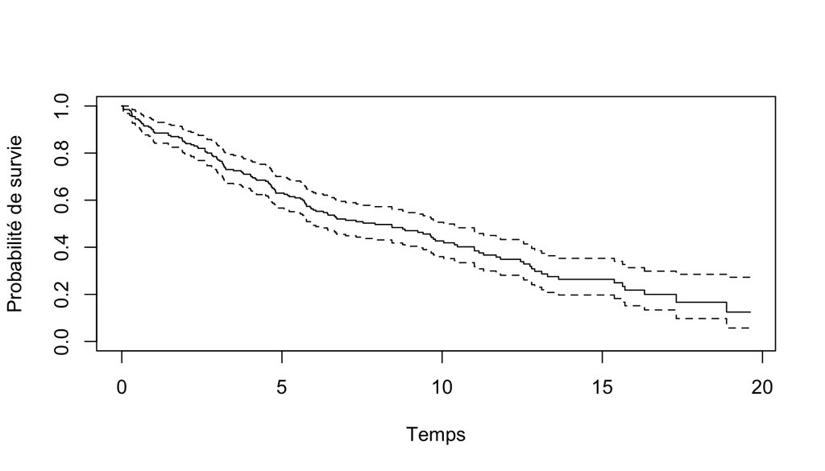

```r
km_sim <- survfit(S_sim ~ 1)
plot(km_sim, xlab = "Temps", ylab = "Probabilité de survie")
```

- la courbe tient compte à la fois des événements observés et des observations censurées.

# 6 Objet de survie en R et interprétation

## 6.1 Surv() en pratique

Pour des données de grève, on construirait :

```r
# Exemple jouet : les six premières durées de StrikeDuration ;
# la dernière (29 jours) est marquée censurée pour montrer la notation « + »
time   <- c(7, 9, 13, 14, 26, 29)
status <- c(1, 1, 1, 1, 1, 0)

S_strikes_ex <- Surv(time = time, event = status)
S_strikes_ex
```

```
[1]  7   9  13  14  26  29+
```

- Chaque ligne est soit `durée` (événement) soit `durée+` (censure).
- Cet objet est ensuite utilisé par toutes les fonctions de survie.

## 6.2 Kaplan–Meier dans R

Pour estimer la fonction de survie :

```r
km_fit <- survfit(S_strikes_ex ~ 1)
km_fit
```

```
Call: survfit(formula = S_strikes_ex ~ 1)

     n events median 0.95LCL 0.95UCL
[1,] 6      5   13.5       9      NA
```

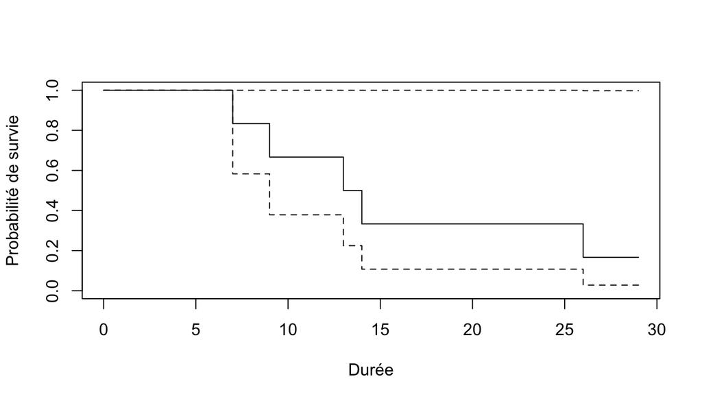

```r
plot(km_fit, xlab = "Durée", ylab = "Probabilité de survie")
```

- Les « marches » de la courbe correspondent aux événements observés.
- Les observations censurées contribuent au **dénominateur** (nombre à risque), mais pas au numérateur (nombre d’événements).

# 7 Résumé des notions clés

## 7.1 À retenir

1. **Durée** $T$ et censure :
   - on observe $(t_i, \delta_i)$, pas toujours la durée vraie.
2. **Fonction de survie** $S(t) = \Pr(T > t)$ :
   - probabilité d’être encore « en vie » au temps $t$.
3. **Risque (hazard)** $h(t)$ :
   - taux instantané de survenue de l’événement, sachant qu’il n’est pas encore arrivé.
4. Liens fondamentaux :
   - $F(t) = 1 - S(t)$,
   - $h(t) = f(t) / S(t)$,
   - $S(t) = \exp\left(-\int_0^t h(u)\,du\right)$.
5. **Censure à droite** :
   - on observe $\min(T_i, C_i)$ et $\mathbb{1}(T_i \le C_i)$,
   - hypothèse clé : censure **non informative**.

## 7.2 Pour la suite du cours

- Estimation de $S(t)$ par l’**estimateur de Kaplan–Meier**.
- Comparaison de courbes de survie entre groupes (test du **log-rank**).
- Modèles à covariables :
  - modèle de Cox (risques proportionnels),
  - modèles paramétriques (exponentiel, Weibull, …).

# 8 Exercices – Correction (survie de grève)

## 8.1 Présentation des données et analyse descriptive

On s’intéresse à la **durée de grèves** dans l’industrie manufacturière américaine.

Les données proviennent de :

> Kennan, J. (1985), *The Duration of Contract Strikes in U.S. Manufacturing*, Journal of Econometrics.

Nous utiliserons la base `StrikeDuration` du package **AER** dans R, qui contient :

- `duration` : durée de la grève (en jours)
- `uoutput` : choc d’activité non anticipé (mesure de conjoncture macroéconomique)

### Avant de commencer : les données et la censure

```r
n_obs  <- nrow(strikes)
n_cens <- sum(strikes$status == 0)

summary(strikes_raw$duration)
```

```
   Min. 1st Qu.  Median    Mean 3rd Qu.    Max.
   1.00   10.25   27.00   42.68   51.25  216.00
```

```r
strikes[strikes$status == 0, c("duration", "uoutput", "time", "status")]
```

```
   duration  uoutput time status
25      216 -0.03957  200      0
```

```r
range(strikes$uoutput)
```

```
[1] -0.10443  0.07427
```

```r
table(strikes$uoutput)   # nombre de grèves par valeur de uoutput
```

```
-0.10443 -0.05467 -0.03957   -0.007  0.00535  0.01138  0.02299   0.0645
       2        3       11        9        3        8        6       18
 0.07427
       2
```

La base compte 62 grèves. Leur durée va de 1 à 216 jours, avec une médiane de 27 jours : la distribution est très asymétrique (moyenne 42,7 jours), avec quelques grèves très longues.

La censure à 200 jours est **artificielle** : elle a été ajoutée pour le TD, afin de manipuler `Surv()` avec au moins une observation censurée. Elle ne touche que 1 grève sur 62 (1,6 % de l’échantillon) : la grève de 216 jours, codée `time = 200`, `status = 0`. Il s’agit d’une censure à droite de type I (seuil fixe, identique pour toutes les grèves), non informative par construction puisque le seuil ne dépend d’aucune caractéristique des grèves. Comme la médiane des durées (27 jours) est très loin de 200, cette censure ne modifie ni les médianes ni, en pratique, les estimations.

La variable `uoutput` varie de -0,104 à 0,074. C’est une mesure agrégée de conjoncture (résidu de la production industrielle après retrait de la tendance et de la saisonnalité). D’après la documentation de **AER** (`?StrikeDuration`), les données originales de Kennan sont mensuelles (janvier 1968 à décembre 1976), mais la version de Greene (2003) reprise dans **AER** ne fournit que les données de juin de chaque année : les grèves d’une même année partagent donc la même valeur. La variable ne prend ainsi que 9 valeurs distinctes pour 62 grèves. Ce point explique plusieurs résultats plus bas (classes d’effectifs inégaux, choix du modèle).

### Q1 – Correspondance entre codages du cycle

On considère les 62 grèves de la base `StrikeDuration`.

On a construit :

- `uoutput_sign` : 2 modalités (cycle défavorable, favorable)
- `uoutput_q` : 3 modalités (choc faible, moyen, fort, par terciles)

#### 1.1 Table de contingence

```r
tab_q1 <- with(strikes, table(uoutput_sign, uoutput_q))
tab_q1
```

```
                   uoutput_q
uoutput_sign        Choc faible Choc moyen Choc fort
  Cycle défavorable          25          0         0
  Cycle favorable             0         17        20
```

#### 1.2 Proportions par ligne

```r
round(100 * prop.table(tab_q1, margin = 1), 1)   # en %
```

```
                   uoutput_q
uoutput_sign        Choc faible Choc moyen Choc fort
  Cycle défavorable       100.0        0.0       0.0
  Cycle favorable           0.0       45.9      54.1
```

```r
table(strikes$uoutput_q)
```

```
Choc faible  Choc moyen   Choc fort
         25          17          20
```

#### 1.3 Les deux échelles sont-elles cohérentes ?

- `uoutput_sign` a bien **deux** modalités observées : 25 grèves en cycle défavorable et 37 en cycle favorable. La modalité « neutre » est prévue par le code (`uoutput == 0`) mais aucune grève n’a un choc exactement nul : elle est vide et n’apparaît pas dans la table.
- La correspondance est **exacte**, pas seulement « à peu près diagonale » :
  - ligne « défavorable » : 100 % des grèves sont en `Choc faible`, et toutes les grèves `Choc faible` sont défavorables (25 grèves sur 25 en `Choc faible`) ;
  - ligne « favorable » : 45,9 % en `Choc moyen` et 54,1 % en `Choc fort`.
- Autrement dit, `Choc faible` coïncide avec « défavorable », et `Choc moyen` + `Choc fort` coïncident avec « favorable ». Les terciles **raffinent** le codage par le signe : ils coupent les cycles favorables en deux. Les deux échelles sont donc cohérentes, et `uoutput_q` contient strictement plus d’information que `uoutput_sign`.
- Remarque sur les « terciles » : les effectifs sont 25 / 17 / 20, pas 1/3 chacun. Le premier groupe contient 40 % des grèves. La raison : `uoutput` ne prend que 9 valeurs, et `cut()` ne peut pas séparer des grèves qui ont la même valeur (le seuil à 33 %, -0,007, est partagé par 9 grèves). C’est aussi pour cela que `Choc faible` regroupe exactement les chocs négatifs : ce seuil est la plus grande valeur négative de `uoutput`. On garde ces seuils tels quels dans tout le TD (les modifier changerait tous les résultats).

### Q2 – Corrélations entre variables explicatives

Variables explicatives potentielles :

- `uoutput` (continu)
- `uoutput_q_num` : version numérique de `uoutput_q` (1 = faible, 2 = moyen, 3 = fort)

#### 2.1 Matrice de corrélation

```r
strikes <- strikes |>
  mutate(uoutput_q_num = as.numeric(uoutput_q))

cor(dplyr::select(strikes, uoutput, uoutput_q_num), use = "complete.obs")
```

```
                uoutput uoutput_q_num
uoutput       1.0000000     0.9245881
uoutput_q_num 0.9245881     1.0000000
```

```r
r_q2 <- cor(strikes$uoutput, strikes$uoutput_q_num)
```

#### 2.2 La version catégorielle apporte-t-elle une information nouvelle ?

- La corrélation vaut r = 0,925, donc r² = 0,85 : 85 % de la variance de `uoutput_q_num` est expliquée linéairement par `uoutput`. C’est attendu : `uoutput_q_num` est une discrétisation monotone de `uoutput`.
- L’information est donc **très largement redondante**. Ce que `uoutput_q_num` change, c’est la forme imposée à la relation :
  - `uoutput_q_num` remplace la valeur exacte du choc par son rang de classe (on perd la variation à l’intérieur d’une classe) et impose des **pas égaux** : passer de faible à moyen aurait le même effet que passer de moyen à fort ;
  - le **facteur** `uoutput_q` (utilisé en Q7) relâche cette contrainte : chaque classe a son propre effet, ce qui permet de repérer une relation non linéaire.
- Conséquence pour la suite : mettre `uoutput` et `uoutput_q_num` **ensemble** dans un modèle (Q6) crée une forte **colinéarité**. Les deux coefficients seront estimés de façon très imprécise.

### Q3 – Courbes de survie brutes (Kaplan–Meier)

#### 3.1 Courbes $\hat S(t)$ par niveau de choc

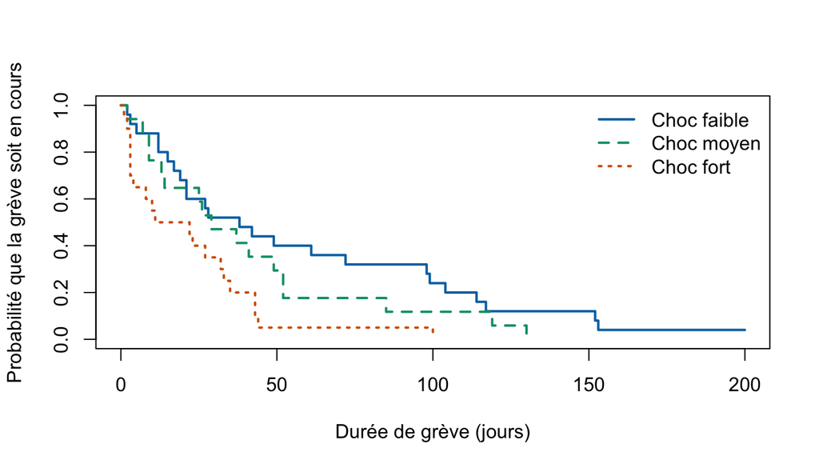

Estimateur de Kaplan–Meier de la probabilité qu’une grève soit encore en cours, par niveau de choc d’activité (terciles de uoutput). Données StrikeDuration (Kennan, 1985), censure artificielle à 200 jours.

```r
km_cycle <- survfit(S_strikes ~ uoutput_q, data = strikes)

cols_q <- c("#0072B2", "#009E73", "#D55E00")   # faible, moyen, fort

plot(
  km_cycle,
  col  = cols_q, lty = 1:3, lwd = 2,
  xlab = "Durée de grève (jours)",
  ylab = "Probabilité que la grève soit en cours"
)
legend(
  "topright",
  legend = levels(strikes$uoutput_q),
  col = cols_q, lty = 1:3, lwd = 2, bty = "n"
)
```

```r
km_cycle                               # médianes par groupe
```

```
Call: survfit(formula = S_strikes ~ uoutput_q, data = strikes)

                       n events median 0.95LCL 0.95UCL
uoutput_q=Choc faible 25     24   38.0      21      99
uoutput_q=Choc moyen  17     17   29.0      14      52
uoutput_q=Choc fort   20     20   16.5       4      35
```

```r
summary(km_cycle, times = c(30, 60))   # survie à 30 et 60 jours
```

```
Call: survfit(formula = S_strikes ~ uoutput_q, data = strikes)

                uoutput_q=Choc faible
 time n.risk n.event survival std.err lower 95% CI upper 95% CI
   30     13      12     0.52  0.0999        0.357        0.758
   60     10       3     0.40  0.0980        0.247        0.646

                uoutput_q=Choc moyen
 time n.risk n.event survival std.err lower 95% CI upper 95% CI
   30      8       9    0.471  0.1211       0.2842        0.779
   60      3       5    0.176  0.0925       0.0632        0.493

                uoutput_q=Choc fort
 time n.risk n.event survival std.err lower 95% CI upper 95% CI
   30      7      13     0.35  0.1067       0.1926        0.636
   60      1       6     0.05  0.0487       0.0074        0.338
```

```r
med_q  <- summary(km_cycle)$table[, "median"]
s_3060 <- summary(km_cycle, times = c(30, 60))
s30 <- s_3060$surv[s_3060$time == 30]   # faible, moyen, fort
s60 <- s_3060$surv[s_3060$time == 60]
```

#### 3.2 Que constate-t-on ?

Comment lire le graphique : chaque marche correspond à une ou plusieurs fins de grève ; la hauteur de la courbe au jour $t$ est la part estimée des grèves du groupe encore en cours après $t$ jours. La médiane se lit là où la courbe passe sous 0,5.

- **Choc fort** (conjoncture la plus favorable) : la courbe est nettement en dessous des deux autres presque dès le début. La durée médiane est de 16,5 jours. La courbe reste exactement à 0,50 entre le jour 11 et le jour 22 ; R prend alors le milieu de ce palier. À 30 jours, 35 % de ces grèves sont encore en cours, et 5 % à 60 jours.
- **Choc faible** (conjoncture défavorable) : médiane de 38 jours ; 52 % des grèves durent encore à 30 jours et 40 % à 60 jours. La courbe ne descend pas à 0 : elle reste à 0,04 jusqu’au jour 200, à cause de la grève censurée (la seule grève de plus de 200 jours appartient à ce groupe).
- **Choc moyen** : médiane de 29 jours, mais la courbe est enchevêtrée avec celle du choc faible pendant le premier mois : les deux courbes se croisent plusieurs fois avant le jour 29. Elles ne se séparent qu’ensuite (18 % encore en cours à 60 jours contre 40 % pour le choc faible).
- Bilan : le classement **fort < moyen < faible** des durées apparaît nettement pour le choc fort, plus tardivement et plus faiblement entre moyen et faible. Les courbes ne sont donc pas « bien séparées » partout.
- Piège : un écart visuel n’est pas un test. Les groupes sont petits (25, 17, 20 grèves) et les intervalles de confiance des médianes sont larges (choc faible : 21 à 99 jours). Il faut un test formel : c’est l’objet de Q4.

### Q4 – Test du log-rank

#### 4.1 Hypothèses

- $H_0$ : $S_{\text{faible}}(t) = S_{\text{moyen}}(t) = S_{\text{fort}}(t)$ pour tout $t$ (de façon équivalente : même fonction de risque dans les trois groupes).
- $H_1$ : au moins une des trois fonctions de survie diffère des autres.

#### 4.2 Statistique et p-valeur

```r
lr_q4 <- survdiff(S_strikes ~ uoutput_q, data = strikes)
lr_q4
```

```
Call:
survdiff(formula = S_strikes ~ uoutput_q, data = strikes)

                       N Observed Expected (O-E)^2/E (O-E)^2/V
uoutput_q=Choc faible 25       24     32.4  2.198928  5.143950
uoutput_q=Choc moyen  17       17     16.9  0.000153  0.000219
uoutput_q=Choc fort   20       20     11.6  6.074740  8.183882

 Chisq= 9.2  on 2 degrees of freedom, p= 0.01
```

```r
p_lr <- 1 - pchisq(lr_q4$chisq, df = length(lr_q4$n) - 1)
```

Intuition : à chaque date où des grèves se terminent, on calcule combien de fins on **attendrait** dans chaque groupe si $H_0$ était vraie (proportionnellement au nombre de grèves encore en cours dans le groupe). On additionne sur toutes les dates les écarts entre fins **observées** (O) et **attendues** (E).

Lecture de la sortie, ligne par ligne :

- `Choc faible` : O = 24 fins observées pour E = 32,4 attendues sous $H_0$. Moins de fins que prévu : les grèves de ce groupe durent plus longtemps.
- `Choc moyen` : O = 17 contre E = 16,9. Pratiquement ce qu’on attendrait sans effet.
- `Choc fort` : O = 20 contre E = 11,6. Nettement plus de fins que prévu : les grèves sont plus courtes.
- La statistique vaut $\chi^2$ = 9,18, avec 2 degrés de liberté (3 groupes moins 1), et la p-valeur vaut 0,010.

#### 4.3 Conclusion au seuil de 5 %

- p = 0,010 < 0,05 : on **rejette** $H_0$. La durée des grèves est significativement associée au niveau de choc d’activité.
- Le test est global : il ne dit pas **quels** groupes diffèrent. La colonne `(O-E)^2/V` donne, pour chaque groupe, la statistique d’un test à 1 ddl de ce groupe contre l’ensemble des autres : choc fort 8,18, choc faible 5,14, choc moyen 0,0002. Ces trois nombres ne s’additionnent pas pour donner le $\chi^2$ global (les groupes ne sont pas indépendants), mais ils indiquent que l’écart à $H_0$ vient des deux groupes extrêmes. Les comparaisons deux à deux viendront avec le modèle de Cox (Q7).
- On écrit « associée à » et non « dépend de » : il s’agit d’une comparaison descriptive, sans autre variable de contrôle.

### Q5 – Vérification graphique des risques proportionnels

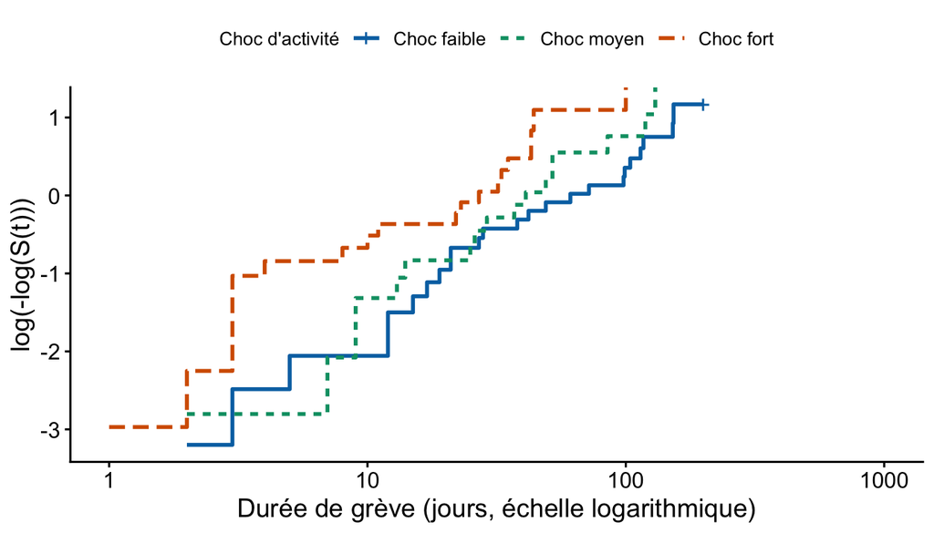

Courbes log(-log(S(t))) de Kaplan–Meier par niveau de choc. L’axe horizontal est en jours sur une échelle logarithmique. Sous l’hypothèse de risques proportionnels, les courbes sont parallèles. Données StrikeDuration.

```r
if (requireNamespace("survminer", quietly = TRUE)) {
  ggsurvplot(
    km_cycle, data = strikes,
    fun          = "cloglog",
    palette      = cols_q,
    linetype     = "strata",
    legend.title = "Choc d'activité",
    legend.labs  = levels(strikes$uoutput_q),
    xlab = "Durée de grève (jours, échelle logarithmique)",
    ylab = "log(-log(S(t)))"
  )
}
```

```r
# S(t) du choc faible aux jours 10 et 100 (utilisé dans le commentaire)
s_f <- summary(km_cycle, times = c(10, 100))$surv[1:2]

# Écarts verticaux entre courbes log(-log(S)) aux jours 11, 21, 30 et 60
j_g  <- c(11, 21, 30, 60)
cll  <- matrix(log(-log(summary(km_cycle, times = j_g)$surv)), ncol = 3,
               dimnames = list(j_g, levels(strikes$uoutput_q)))
gaps <- cbind(fort_moins_faible  = cll[, 3] - cll[, 1],
              moyen_moins_faible = cll[, 2] - cll[, 1])
round(gaps, 2)
```

```
   fort_moins_faible moyen_moins_faible
11              1.69               0.74
21              0.31              -0.16
30              0.47               0.14
60              1.18               0.64
```

```r
b_fort <- coef(coxph(S_strikes ~ uoutput_q, data = strikes))[2]
```

Pourquoi ce graphique ? Sous l’hypothèse de risques proportionnels, $h_g(t) = h_0(t)\exp(\beta_g)$ pour le groupe $g$, donc $S_g(t) = S_0(t)^{\exp(\beta_g)}$ et

$$\log\big(-\log S_g(t)\big) = \log \Lambda_0(t) + \beta_g .$$

Les courbes des différents groupes sont la **même** courbe $\log \Lambda_0(t)$ décalée verticalement de $\beta_g$ : elles doivent être parallèles, avec un écart constant.

#### 5.1 Les courbes sont-elles parallèles ?

- La courbe du choc fort est au-dessus des deux autres sur toute la période : risque cumulé plus élevé, grèves plus courtes. L’écart vertical avec le choc faible n’est pas constant : il vaut 1,69 au jour 11, 0,31 au jour 21 et 1,18 au jour 60. Il fluctue autour de la valeur que le modèle de Cox attribue au choc fort ($\hat\beta_3$ = 0,96, Q7), sans tendance à croître ou à décroître avec le temps. Avec 20 et 25 grèves dans ces deux groupes, de telles fluctuations sont compatibles avec le bruit d’échantillonnage ; le test de Schoenfeld ci-dessous va dans le même sens. Au-delà de 100 jours, il reste très peu de grèves en cours et les courbes deviennent peu informatives.
- Les courbes du choc faible et du choc moyen s’entrecroisent pendant le premier mois (ce sont les croisements des courbes de Kaplan–Meier vus en Q3), puis s’écartent modérément : l’écart moyen − faible passe de 0,14 au jour 30 à 0,64 au jour 60.
- Ces croisements ne sont pas un argument fort contre les risques proportionnels : si le rapport de risques instantanés (*hazard ratio*, HR) entre moyen et faible est statistiquement indiscernable de 1 (on trouvera en Q7 un HR de 1,43, avec un intervalle de confiance qui contient 1), les deux courbes doivent être proches, et le bruit d’échantillonnage suffit à les faire se croiser. Un vrai problème serait un écart qui change de sens durablement ou évolue régulièrement au cours du temps.

Le graphique se complète par un test formel fondé sur les **résidus de Schoenfeld** : si l’effet d’une variable varie dans le temps, ces résidus sont corrélés au temps.

```r
zph_cat <- cox.zph(coxph(S_strikes ~ uoutput_q, data = strikes))
zph_M1  <- cox.zph(cox_uoutput)
zph_cat
```

```
          chisq df    p
uoutput_q 0.311  2 0.86
GLOBAL    0.311  2 0.86
```

```r
zph_M1
```

```
          chisq df    p
uoutput 0.00662  1 0.94
GLOBAL  0.00662  1 0.94
```

- Pour `uoutput_q` : p = 0,86.
- Pour `uoutput` en continu : p = 0,94.
- Dans les deux cas, aucun signe de violation de l’hypothèse (l’hypothèse nulle du test est la proportionnalité des risques).

#### 5.2 Plausibilité du modèle de Cox

L’hypothèse de risques proportionnels est **plausible** pour le choc d’activité, qu’on le mesure en classes ou en continu : le modèle de Cox est utilisable. Avec 62 grèves, ces diagnostics ont peu de puissance : ils ne détectent que des violations marquées.

Lien avec la suite (Q10) : pour une loi de Weibull, $\log \Lambda(t) = \log \lambda + p \log t$. Sur ce graphique (axe horizontal en $\log t$), un modèle de Weibull donne des **droites parallèles de pente $p$**, et un risque constant (loi exponentielle) des droites de pente 1. Ici, entre 10 et 100 jours, la courbe du choc faible monte de 2,4 unités quand $t$ est multiplié par 10 (soit $\log 10 \approx 2{,}3$ en abscisse) : une pente proche de 1, ce que Q10 confirmera.

## 8.2 Modèle de Cox – Correction

### Q6 – Modèle de Cox avec uoutput et uoutput_q_num

#### 6.1 Équation du modèle

$$h_i(t) = h_0(t)\,\exp\big(\beta_1\, \mathtt{uoutput}_i + \beta_2\, \mathtt{uoutput\_q\_num}_i\big)$$

- $h_i(t)$ : risque instantané que la grève $i$ se termine au jour $t$, sachant qu’elle dure encore ;
- $h_0(t)$ : **risque de base**, commun à toutes les grèves, laissé totalement libre (non paramétrique) ; il absorbe la constante, d’où l’absence d’ordonnée à l’origine ;
- $\exp(\beta_1)$ est le **rapport de risques instantanés** (*hazard ratio*, HR) associé à une hausse d’une unité de `uoutput`, `uoutput_q_num` étant fixé.

Dans tout ce document, $\beta$ désigne les coefficients d’un modèle à risques proportionnels (Cox), et $\gamma$ ceux d’un modèle à temps accéléré (Q10). Chaque modèle a ses propres $\beta$ : le $\beta_2$ de Q6 et celui de Q7 ne mesurent pas la même chose.

#### 6.2 Estimation

```r
cox_full <- coxph(S_strikes ~ uoutput + uoutput_q_num, data = strikes)
summary(cox_full)
```

```
Call:
coxph(formula = S_strikes ~ uoutput + uoutput_q_num, data = strikes)

  n= 62, number of events= 61

                  coef exp(coef) se(coef)     z Pr(>|z|)
uoutput         5.5249  250.8571  10.3206 0.535    0.592
uoutput_q_num   0.2007    1.2223   0.5385 0.373    0.709

              exp(coef) exp(-coef) lower .95 upper .95
uoutput         250.857   0.003986 4.117e-07 1.529e+11
uoutput_q_num     1.222   0.818155 4.254e-01 3.512e+00

Concordance= 0.608  (se = 0.041 )
Likelihood ratio test= 8.57  on 2 df,   p=0.01
Wald test            = 8.5  on 2 df,   p=0.01
Score (logrank) test = 8.83  on 2 df,   p=0.01
```

```r
AIC(cox_full)
```

```
[1] 389.1666
```

```r
cf_full <- summary(cox_full)$coefficients
lt_full <- summary(cox_full)$logtest
```

#### 6.3 Interprétation du hazard ratio de `uoutput`

Lecture de la ligne `uoutput` :

- `coef` = 5,52 : estimation de $\beta_1$. Le signe est positif : un choc plus favorable va avec un risque de fin **plus élevé**, donc des grèves plus courtes.
- `exp(coef)` = 250,86 : le HR pour une hausse d’**une unité** de `uoutput`. Ce chiffre spectaculaire n’a pas de sens concret : `uoutput` varie de -0,104 à 0,074, une hausse d’une unité représente donc 5,6 fois l’étendue totale des données. Pour une hausse réaliste de 0,01, le HR vaut $\exp(0{,}01\,\hat\beta_1)$ = 1,057.
- `se(coef)` = 10,32, soit près de deux fois le coefficient : z = 0,54, p = 0,592. L’effet de `uoutput` n’est **pas significatif** dans ce modèle, et l’intervalle de confiance du HR est absurde (de quasiment 0 à plus de $10^{11}$).
- Même chose pour `uoutput_q_num` : HR = 1,22, p = 0,709.
- Pourtant, le test global du rapport de vraisemblance vaut 8,57 pour 2 ddl, p = 0,014 : **ensemble**, les deux variables expliquent significativement la durée.

Ce contraste (chaque coefficient non significatif, le test global significatif) est le symptôme classique de la **colinéarité** annoncée en Q2 (r = 0,925). « À `uoutput_q_num` fixé » signifie « en faisant varier `uoutput` seulement à l’intérieur d’une classe », et les données contiennent très peu de cette variation. Le modèle sait que la conjoncture compte, mais ne sait pas à quelle variable attribuer l’effet. Le HR de `uoutput` se lit donc mieux dans le modèle M1, qui ne contient que `uoutput` (Q9).

#### 6.4 Critère AIC

$$\text{AIC} = -2 \log L + 2k ,$$

où $\log L$ est ici la log-vraisemblance **partielle** de Cox et $k$ le nombre de coefficients. Pour ce modèle, $-2\log L$ = 385,17 et $k = 2$, d’où **AIC = 389,17**. On le note pour la comparaison de Q9 : plus l’AIC est faible, meilleur est le compromis entre ajustement et nombre de paramètres.

### Q7 – Version purement catégorielle du cycle

#### 7.1 Équation du modèle

$$h_i(t) = h_0(t)\,\exp\big(\beta_2\,\mathbb{1}\{\mathtt{uoutput\_q}_i = \text{Choc moyen}\} + \beta_3\,\mathbb{1}\{\mathtt{uoutput\_q}_i = \text{Choc fort}\}\big)$$

`Choc faible` est la catégorie de référence (son risque est $h_0(t)$) : $\exp(\beta_2)$ est le HR « moyen contre faible » et $\exp(\beta_3)$ le HR « fort contre faible ».

```r
cox_cat <- coxph(S_strikes ~ uoutput_q, data = strikes)
summary(cox_cat)
```

```
Call:
coxph(formula = S_strikes ~ uoutput_q, data = strikes)

  n= 62, number of events= 61

                      coef exp(coef) se(coef)     z Pr(>|z|)
uoutput_qChoc moyen 0.3556    1.4271   0.3253 1.093  0.27435
uoutput_qChoc fort  0.9643    2.6229   0.3265 2.954  0.00314 **
---
Signif. codes:  0 '***' 0.001 '**' 0.01 '*' 0.05 '.' 0.1 ' ' 1

                    exp(coef) exp(-coef) lower .95 upper .95
uoutput_qChoc moyen     1.427     0.7007    0.7543     2.700
uoutput_qChoc fort      2.623     0.3813    1.3832     4.974

Concordance= 0.604  (se = 0.039 )
Likelihood ratio test= 8.47  on 2 df,   p=0.01
Wald test            = 8.81  on 2 df,   p=0.01
Score (logrank) test = 9.3  on 2 df,   p=0.01
```

```r
ci_cat <- summary(cox_cat)$conf.int
cf_cat <- summary(cox_cat)$coefficients
lt_cat <- summary(cox_cat)$logtest
```

#### 7.2 Existe-t-il une différence significative entre au moins deux niveaux ?

La question porte sur **au moins deux** niveaux : la bonne statistique est le test global (2 ddl), pas les tests individuels.

- Test global du rapport de vraisemblance : 8,47 pour 2 ddl, p = 0,015. **Oui**, au seuil de 5 %, au moins deux niveaux de choc diffèrent.
- Fort contre faible : HR = 2,62, IC à 95 % [1,38 ; 4,97], p = 0,003. À chaque date, une grève en choc fort a un taux instantané de fin environ 2,6 fois plus élevé qu’une grève en choc faible qui dure depuis aussi longtemps. L’intervalle exclut 1 : différence significative.
- Moyen contre faible : HR = 1,43, IC [0,75 ; 2,70], p = 0,274. L’intervalle contient 1 : on ne distingue pas ces deux groupes (cohérent avec les courbes qui se croisent en Q3).
- Fort contre moyen : la sortie ne le donne pas directement ; on change de catégorie de référence avec `relevel()` :

```r
cox_cat_moy <- coxph(
  S_strikes ~ relevel(uoutput_q, ref = "Choc moyen"), data = strikes
)
ci_moy <- summary(cox_cat_moy)$conf.int
cf_moy <- summary(cox_cat_moy)$coefficients
round(ci_moy, 3)
```

```
                                                  exp(coef) exp(-coef)
relevel(uoutput_q, ref = "Choc moyen")Choc faible     0.701      1.427
relevel(uoutput_q, ref = "Choc moyen")Choc fort       1.838      0.544
                                                  lower .95 upper .95
relevel(uoutput_q, ref = "Choc moyen")Choc faible     0.370     1.326
relevel(uoutput_q, ref = "Choc moyen")Choc fort       0.946     3.571
```

- Fort contre moyen : HR = 1,84, IC [0,95 ; 3,57], p = 0,072 : non significatif à 5 %.
- Bilan : les HR croissent avec le choc (1 ; 1,43 ; 2,62), mais avec 17 à 25 grèves par groupe, seule la comparaison des deux extrêmes est nette.

Remarque : la ligne `Score (logrank) test` de la sortie (9,30) est proche du log-rank de Q4 (9,18). Le test du log-rank **est** le test du score du modèle de Cox à variable qualitative ; la petite différence vient du traitement des durées ex aequo (plusieurs grèves finissant le même jour) : `coxph()` utilise par défaut une approximation (méthode d’Efron), alors que le log-rank fait le calcul exact. Avec `ties = "exact"`, on retrouve exactement la valeur de Q4 : 9,18.

#### 7.3 Comparaison des déviances avec le modèle de Q6

`summary()` n’affiche pas la log-vraisemblance : on l’obtient avec `logLik()`.

```r
dev_q7 <- c(
  cox_full = -2 * as.numeric(logLik(cox_full)),
  cox_cat  = -2 * as.numeric(logLik(cox_cat))
)
round(dev_q7, 2)
```

```
cox_full  cox_cat
  385.17   385.27
```

- Déviance $-2\log L$ : 385,17 pour le modèle de Q6, 385,27 pour le modèle catégoriel.
- Les deux modèles ont 2 paramètres et ne sont pas emboîtés (Q8) : pas de test du rapport de vraisemblance possible, mais à nombre de paramètres égal, comparer les déviances revient à comparer les AIC.
- L’écart est de 0,10 point : négligeable. Les deux modèles s’ajustent **aussi bien** l’un que l’autre. Savoir si l’un capte une information que l’autre manque demande un modèle qui les contienne tous deux : c’est l’objet de M4 en Q9.

### Q8 – Nombre de paramètres et emboîtement

Modèles :

- M1 : `S ~ uoutput`
- M2 : `S ~ uoutput + uoutput_q_num`
- M3 : `S ~ uoutput_q` (facteur 3 modalités)

#### 8.1 Nombre de paramètres de pente

| Modèle | Variables | Paramètres de pente |
| --- | --- | --- |
| M1 | `uoutput` | 1 ($\beta_1$) |
| M2 | `uoutput` + `uoutput_q_num` | 2 ($\beta_1$, $\beta_2$) |
| M3 | `uoutput_q` (facteur) | 2 (une indicatrice pour `Choc moyen`, une pour `Choc fort`) |

Le risque de base $h_0(t)$ n’est jamais compté : il n’est pas estimé comme un paramètre dans la vraisemblance partielle de Cox.

#### 8.2 Relations d’emboîtement

Un modèle est emboîté dans un autre s’il s’obtient en imposant des contraintes sur les paramètres du second.

- **M1 $\subset$ M2** : M1 est M2 avec la contrainte $\beta_2 = 0$.
- **M3 n’est pas emboîté dans M1**, ni M1 dans M3 : M1 impose un effet linéaire en `uoutput` (valeur exacte), M3 un effet en escalier constant à l’intérieur de chaque classe. Aucune contrainte sur les paramètres de l’un ne donne l’autre.
- **M3 et M2 ne sont pas emboîtés** non plus : M2 contient `uoutput`, absent de M3 ; M3 autorise des pas inégaux entre classes, que M2 interdit.
- Un modèle **englobant** les contient tous : M4 = `S ~ uoutput + uoutput_q` (facteur, 3 paramètres). M1 s’obtient en annulant les deux indicatrices, M3 en annulant le coefficient de `uoutput`, et M2 en imposant que l’effet de `Choc fort` soit le double de celui de `Choc moyen` (pas égaux, puisque `uoutput_q_num` vaut 1, 2, 3). On a donc M1 $\subset$ M2 $\subset$ M4 et M3 $\subset$ M4. M4 sert en Q9 à comparer M1 et M3 proprement.

### Q9 – Choix de la meilleure mesure du cycle

#### 9.1 Tests du rapport de vraisemblance

```r
cox_M1 <- coxph(S_strikes ~ uoutput, data = strikes)
cox_M2 <- coxph(S_strikes ~ uoutput + uoutput_q_num, data = strikes)
cox_M3 <- coxph(S_strikes ~ uoutput_q, data = strikes)
cox_M4 <- coxph(S_strikes ~ uoutput + uoutput_q, data = strikes)  # englobant

a12 <- anova(cox_M1, cox_M2, test = "LRT")
a13 <- anova(cox_M1, cox_M3, test = "LRT")   # piège : modèles non emboîtés
a14 <- anova(cox_M1, cox_M4, test = "LRT")
a34 <- anova(cox_M3, cox_M4, test = "LRT")
a12
```

```
Analysis of Deviance Table
 Cox model: response is  S_strikes
 Model 1: ~ uoutput
 Model 2: ~ uoutput + uoutput_q_num
   loglik  Chisq Df Pr(>|Chi|)
1 -192.65
2 -192.58 0.1389  1     0.7094
```

```r
a13
```

```
Analysis of Deviance Table
 Cox model: response is  S_strikes
 Model 1: ~ uoutput
 Model 2: ~ uoutput_q
   loglik  Chisq Df Pr(>|Chi|)
1 -192.65
2 -192.63 0.0382  1      0.845
```

Le test du rapport de vraisemblance compare $LR = 2(\log L_{\text{grand}} - \log L_{\text{petit}})$ à une loi du $\chi^2$ dont le nombre de degrés de liberté est le nombre de contraintes. Il n’est valide que si le petit modèle est **emboîté** dans le grand.

- **M1 contre M2** (emboîtés) : LR = 0,139, 1 ddl, p = 0,709. Ajouter `uoutput_q_num` à `uoutput` n’améliore pas significativement l’ajustement : on garde M1.
- **M1 contre M3** : R affiche LR = 0,038, 1 ddl, p = 0,845. **Piège : ce test n’est pas valide.** M1 et M3 ne sont pas emboîtés (Q8) ; `anova()` calcule quand même la différence des log-vraisemblances et la différence du nombre de paramètres (2 − 1), sans vérifier l’emboîtement. Sous $H_0$, cette statistique ne suit pas une loi du $\chi^2$ à 1 ddl : la p-valeur n’a pas de sens.
- La façon correcte de comparer M1 et M3 passe par le modèle englobant M4 :

```r
a14
```

```
Analysis of Deviance Table
 Cox model: response is  S_strikes
 Model 1: ~ uoutput
 Model 2: ~ uoutput + uoutput_q
   loglik  Chisq Df Pr(>|Chi|)
1 -192.65
2 -192.47 0.3621  2     0.8344
```

```r
a34
```

```
Analysis of Deviance Table
 Cox model: response is  S_strikes
 Model 1: ~ uoutput_q
 Model 2: ~ uoutput + uoutput_q
   loglik  Chisq Df Pr(>|Chi|)
1 -192.63
2 -192.47 0.3239  1     0.5693
```

- M1 contre M4 : LR = 0,362, 2 ddl, p = 0,834. Ajouter les classes à `uoutput` n’apporte rien.
- M3 contre M4 : LR = 0,324, 1 ddl, p = 0,569. Ajouter `uoutput` aux classes n’apporte rien non plus.
- Aucun des deux modèles n’est rejeté face au modèle englobant : les données **ne permettent pas de trancher** entre mesure continue et mesure en classes par un test. Le choix se fait donc sur l’AIC et sur des arguments de fond.

#### 9.2 Combinaison avec les AIC

```r
aic_cox <- AIC(cox_M1, cox_M2, cox_M3, cox_M4)
aic_cox$logLik <- sapply(list(cox_M1, cox_M2, cox_M3, cox_M4),
                         function(m) as.numeric(logLik(m)))
round(aic_cox, 2)
```

```
       df    AIC  logLik
cox_M1  1 387.31 -192.65
cox_M2  2 389.17 -192.58
cox_M3  2 389.27 -192.63
cox_M4  3 390.94 -192.47
```

- AIC : M1 = 387,31, M2 = 389,17, M3 = 389,27, M4 = 390,94.
- Les log-vraisemblances sont presque identiques (de -192,65 à -192,47) : les quatre modèles s’ajustent aussi bien. L’AIC départage alors par le nombre de paramètres, et **M1 a le plus petit AIC** (environ 2 points de moins que M2 et M3).
- Tests et AIC ne se contredisent pas : aucun test ne rejette M1, et l’AIC ne le préfère que par parcimonie (l’écart d’environ 2 points correspond au coût d’un paramètre supplémentaire, pas à un meilleur ajustement). **On retient M1**, la mesure continue `uoutput` seule. C’est ce modèle qu’on utilise dans les questions 10 et 11.

#### 9.3 Justification économique et économétrique

Arguments économétriques :

- parcimonie : un seul paramètre pour le même ajustement, d’où le meilleur AIC ;
- pas de seuils arbitraires : les terciles dépendent de l’échantillon et, à cause des ex aequo, ne sont même pas des tiers (Q1) ;
- pas de colinéarité : le coefficient est estimé nettement plus précisément qu’en M2 (écart-type 3,23 contre 10,32, voir ci-dessous) ;
- l’hypothèse de risques proportionnels n’est pas rejetée pour `uoutput` (Q5, p = 0,94) ;
- l’effet en escalier de M3 est monotone (log-HR de 0, 0,36 et 0,96), ce qui est compatible avec un effet linéaire de `uoutput` ; rien n’indique une non-linéarité qui justifierait le découpage.

Arguments économiques :

- `uoutput` mesure l’écart de l’activité à sa valeur anticipée : c’est une grandeur continue, et la question économique est un effet « dose-réponse » (de combien le risque de fin varie quand la conjoncture s’améliore d’un cran) ;
- les seuils des terciles n’ont pas de signification économique : deux grèves de part et d’autre d’un seuil n’ont pas des conjonctures très différentes.

Limite : `uoutput` ne prend que peu de valeurs distinctes (voir la présentation des données), donc « continu » signifie ici quelques points ordonnés sur une droite. Avec 62 grèves, on ne peut pas tester de non-linéarité fine.

Lecture du modèle retenu :

```r
summary(cox_M1)
```

```
Call:
coxph(formula = S_strikes ~ uoutput, data = strikes)

  n= 62, number of events= 61

             coef exp(coef)  se(coef)     z Pr(>|z|)
uoutput     9.216 10060.629     3.229 2.855  0.00431 **
---
Signif. codes:  0 '***' 0.001 '**' 0.01 '*' 0.05 '.' 0.1 ' ' 1

        exp(coef) exp(-coef) lower .95 upper .95
uoutput     10061   9.94e-05     17.96   5634413

Concordance= 0.608  (se = 0.041 )
Likelihood ratio test= 8.43  on 1 df,   p=0.004
Wald test            = 8.15  on 1 df,   p=0.004
Score (logrank) test = 8.31  on 1 df,   p=0.004
```

```r
b_M1   <- coef(cox_M1)["uoutput"]
se_M1  <- sqrt(vcov(cox_M1)["uoutput", "uoutput"])
p_M1   <- summary(cox_M1)$coefficients["uoutput", "Pr(>|z|)"]
iqr_u  <- IQR(strikes$uoutput)
hr_001 <- exp(0.01 * b_M1)
ci_001 <- exp(0.01 * confint(cox_M1))
hr_iqr <- exp(iqr_u * b_M1)
c(HR_plus_0.01 = hr_001, IC_bas = ci_001[1], IC_haut = ci_001[2],
  HR_ecart_interquartile = hr_iqr)
```

```
          HR_plus_0.01.uoutput                         IC_bas
                      1.096544                       1.029305
                       IC_haut HR_ecart_interquartile.uoutput
                      1.168177                       2.420816
```

- $\hat\beta_1$ = 9,216 (écart-type 3,229), p = 0,004 : seul, `uoutput` est significatif. Comparez avec l’écart-type de 10,32 dans M2 : c’est le coût de la colinéarité.
- Une hausse de 0,01 du choc multiplie le risque instantané de fin de grève par 1,097 (IC à 95 % [1,029 ; 1,168]) : environ +10 %.
- Passer du premier au troisième quartile de `uoutput` (écart interquartile de 0,096) multiplie ce risque par 2,42.

## 8.3 Modèles paramétriques – Correction

### Q10 – Modèle de Weibull

#### 10.1 Estimation

On reprend la variable retenue en Q9, `uoutput`.

```r
weib_best <- survreg(S_strikes ~ uoutput, data = strikes, dist = "weibull")
summary(weib_best)
```

```
Call:
survreg(formula = S_strikes ~ uoutput, data = strikes, dist = "weibull")
               Value Std. Error     z      p
(Intercept)  3.79012    0.13944 27.18 <2e-16
uoutput     -9.67700    3.00825 -3.22 0.0013
Log(scale)   0.00631    0.10180  0.06 0.9506

Scale= 1.01

Weibull distribution
Loglik(model)= -285.4   Loglik(intercept only)= -290.2
    Chisq= 9.6 on 1 degrees of freedom, p= 0.002
Number of Newton-Raphson Iterations: 6
n= 62
```

```r
alpha_w <- coef(weib_best)["(Intercept)"]
gamma_w <- coef(weib_best)["uoutput"]
sigma_w <- weib_best$scale
p_w     <- 1 / sigma_w              # paramètre de forme
beta_ph <- -gamma_w / sigma_w       # coefficient en écriture PH
tab_w   <- summary(weib_best)$table
med_w0  <- predict(weib_best, newdata = data.frame(uoutput = 0),
                   type = "quantile", p = 0.5)
med_wm  <- predict(weib_best,
                   newdata = data.frame(uoutput = median(strikes$uoutput)),
                   type = "quantile", p = 0.5)
```

`survreg()` n’écrit pas le modèle comme un modèle de risque, mais comme un modèle à **temps de vie accéléré** (AFT) sur le logarithme de la durée :

$$\log T_i = \alpha + \gamma\, \mathtt{uoutput}_i + \sigma W_i ,$$

où $W_i$ suit une loi des valeurs extrêmes (minimum). On note $\gamma$ le coefficient AFT pour ne pas le confondre avec le $\beta$ d’un modèle de Cox. Lecture de la sortie :

- `(Intercept)` : $\hat\alpha$ = 3,79.
- `uoutput` : $\hat\gamma$ = -9,68 (écart-type 3,01, p = 0,001). Le signe est **négatif**, alors que $\beta$ était positif dans le modèle de Cox : ce n’est pas une contradiction. Ici le coefficient porte sur la **durée** (un choc favorable la raccourcit), là il portait sur le **risque de fin** (un choc favorable l’augmente).
- `Log(scale)` : $\log\hat\sigma$ = 0,0063, p = 0,95, et `Scale` = $\hat\sigma$ = 1,006.

Lecture en **rapport de durées** (*time ratio*) : $\exp(0{,}01\,\hat\gamma)$ = 0,908. Une hausse de 0,01 du choc multiplie toute la distribution des durées (médiane, quartiles…) par 0,908, soit des grèves environ 9 % plus courtes. Sur l’écart interquartile, le facteur est 0,40 : les durées sont à peu près divisées par 2,5.

Passage à l’écriture en risques proportionnels. La famille Weibull (dont l’exponentielle est un cas particulier) est la seule à être à la fois AFT et PH :

$$h_i(t) = \lambda\, p\, t^{p-1} \exp(\beta\, \mathtt{uoutput}_i), \qquad p = \frac{1}{\sigma}, \quad \beta = -\frac{\gamma}{\sigma}, \quad \lambda = e^{-\alpha/\sigma}.$$

- Forme : $\hat p = 1/\hat\sigma$ = 0,994, pratiquement 1. Le test de Wald de `Log(scale)` = 0 (c’est-à-dire $\sigma = p = 1$) donne p = 0,95 : on ne rejette pas un **risque constant** (loi exponentielle).
- Coefficient PH : $\hat\beta = -\hat\gamma/\hat\sigma$ = 9,62, très proche du $\hat\beta_1$ du Cox M1 (9,22). Les deux modèles racontent la même chose sur l’effet du cycle : c’est un bon contrôle de cohérence.
- Piège sur la constante : $\exp(\hat\alpha)$ = 44,3 jours n’est **pas** la durée médiane. C’est le paramètre d’échelle de la Weibull pour `uoutput` = 0 (la durée que 63 % des grèves n’atteignent pas). La médiane prédite vaut 30,6 jours pour `uoutput` = 0 et 27,4 jours pour la valeur médiane de `uoutput`, à comparer à la médiane observée de toutes les grèves (27 jours, identique ici à la médiane de Kaplan–Meier car la seule durée censurée est au-delà).

#### 10.2 Nombre de paramètres

**Trois** paramètres sont estimés : l’ordonnée à l’origine $\alpha$, le coefficient $\gamma$ de `uoutput`, et le paramètre d’échelle $\sigma$ (estimé sous la forme $\log\sigma$, ligne `Log(scale)`), qui fixe la forme $p = 1/\sigma$. R le confirme : `logLik(weib_best)` a 3 degrés de liberté. Contrairement au Cox, le risque de base est ici entièrement paramétré ($\alpha$ et $\sigma$ le décrivent).

#### 10.3 Comparaison de l’AIC avec celui du Cox retenu

```r
c(AIC_Cox_M1 = AIC(cox_M1), AIC_Weibull = AIC(weib_best))
```

```
 AIC_Cox_M1 AIC_Weibull
   387.3055    576.7054
```

- R donne AIC = 387,31 pour le Cox M1 et 576,71 pour la Weibull.
- **Ces deux nombres ne sont pas comparables**, et l’écart d’environ 189 points ne signifie pas que le Cox est meilleur. L’AIC de `coxph()` est calculé à partir de la vraisemblance **partielle**, qui n’utilise que l’ordre des fins de grève (le risque de base n’est pas estimé). Celui de `survreg()` utilise la vraisemblance **complète** des durées observées. Ce sont deux fonctions différentes, sur deux échelles différentes.
- Les comparaisons valides sont :
  1. entre modèles **paramétriques** estimés par vraisemblance complète sur les mêmes données (tableau ci-dessous) ;
  2. entre le Cox et la Weibull, en comparant les **coefficients** (fait plus haut : 9,62 contre 9,22) et les **courbes prédites** (Q11).

```r
expo_m <- survreg(S_strikes ~ uoutput, data = strikes, dist = "exponential")
logn_m <- survreg(S_strikes ~ uoutput, data = strikes, dist = "lognormal")
logl_m <- survreg(S_strikes ~ uoutput, data = strikes, dist = "loglogistic")

param_comp <- data.frame(
  modele = c("Exponentielle", "Weibull", "Log-normale", "Log-logistique"),
  k      = sapply(list(expo_m, weib_best, logn_m, logl_m),
                  function(m) attr(logLik(m), "df")),
  logLik = sapply(list(expo_m, weib_best, logn_m, logl_m),
                  function(m) as.numeric(logLik(m))),
  AIC    = sapply(list(expo_m, weib_best, logn_m, logl_m), AIC)
)
param_comp$logLik <- round(param_comp$logLik, 2)
param_comp$AIC    <- round(param_comp$AIC, 2)
param_comp
```

```
          modele k  logLik    AIC
1  Exponentielle 2 -285.35 574.71
2        Weibull 3 -285.35 576.71
3    Log-normale 3 -287.36 580.72
4 Log-logistique 3 -288.59 583.19
```

```r
a_ew <- anova(expo_m, weib_best)   # exponentielle emboîtée dans Weibull
a_ew
```

```
    Terms Resid. Df    -2*LL Test Df    Deviance  Pr(>Chi)
1 uoutput        60 570.7093      NA          NA        NA
2 uoutput        59 570.7054    =  1 0.003856221 0.9504844
```

- Exponentielle contre Weibull (emboîtés : l’exponentielle est la Weibull avec $\sigma = 1$) : LR = 0,0039, 1 ddl, p = 0,95. Le paramètre de forme n’améliore pas l’ajustement, et l’AIC de l’exponentielle (574,71) est plus bas que celui de la Weibull (576,71).
- Log-normale (580,72) et log-logistique (583,19) ont des AIC plus élevés : ces lois, qui autorisent un risque d’abord croissant puis décroissant, s’ajustent moins bien.
- Conclusion : la Weibull est cohérente avec le Cox (même effet du cycle) et décrit bien les données, mais sa forme estimée la ramène à une **exponentielle**, que l’AIC préfère de peu. On garde la Weibull demandée par l’énoncé, en sachant qu’un modèle exponentiel ferait aussi bien.

### Q11 – Courbes de survie et risque instantané

On compare trois scénarios de conjoncture : les quantiles à 20 %, 50 % et 80 % de `uoutput`.

```r
sc <- data.frame(uoutput = quantile(strikes$uoutput, probs = c(.2, .5, .8)))
sc
```

```
     uoutput
20% -0.03957
50%  0.01138
80%  0.06450
```

```r
lp_w <- predict(weib_best, newdata = sc, type = "lp")   # alpha + gamma * x
```

Le scénario P20 (-0,040) correspond à un choc négatif (cycle défavorable), P50 (0,011) et P80 (0,065) à des chocs positifs.

#### 11.1 Courbes de survie par scénario

On trace les courbes prédites par le Cox M1 (en escalier, car le risque de base est non paramétrique) et par la Weibull (courbes lisses), avec une couleur par scénario.

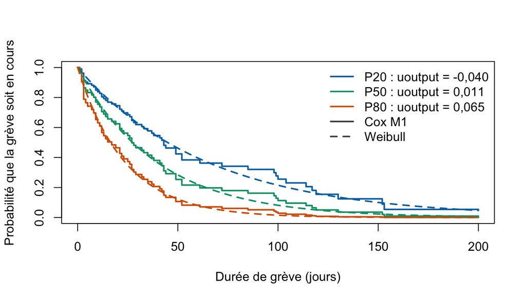

Probabilité prédite qu’une grève soit encore en cours, pour trois valeurs de uoutput (quantiles 20 %, 50 %, 80 %). Traits pleins : modèle de Cox M1 ; tirets : modèle de Weibull. Données StrikeDuration, censure à 200 jours.

```r
cols_sc  <- c("#0072B2", "#009E73", "#D55E00")   # P20, P50, P80
surv_cox <- survfit(cox_M1, newdata = sc)
t_grid   <- seq(0, 200, by = 1)

plot(surv_cox, col = cols_sc, lty = 1, lwd = 2, conf.int = FALSE,
     xlab = "Durée de grève (jours)",
     ylab = "Probabilité que la grève soit en cours")
for (k in 1:3) {
  lines(t_grid,
        pweibull(t_grid, shape = 1 / sigma_w, scale = exp(lp_w[k]),
                 lower.tail = FALSE),
        col = cols_sc[k], lty = 2, lwd = 2)
}
legend("topright",
       legend = c(paste0(c("P20", "P50", "P80"), " : uoutput = ",
                         fmt(sc$uoutput, 3)),
                  "Cox M1", "Weibull"),
       col = c(cols_sc, "grey30", "grey30"),
       lty = c(1, 1, 1, 1, 2), lwd = 2, bty = "n")
```

```r
med_cox <- summary(surv_cox)$table[, "median"]
med_wsc <- predict(weib_best, newdata = sc, type = "quantile", p = 0.5)
s_cox   <- summary(surv_cox, times = c(30, 60))$surv   # lignes : 30, 60
```

- Sous l’hypothèse de risques proportionnels, $S_x(t) = S_0(t)^{\exp(\beta x)}$ : les courbes ne se croisent pas, et celle du choc le plus favorable est toujours en dessous.
- Médianes prédites (Cox / Weibull) : P20 43 / 44,9 jours, P50 27 / 27,4 jours, P80 17 / 16,4 jours.
- Probabilité qu’une grève dure encore à 30 jours (Cox) : 0,62, 0,47 et 0,29 ; à 60 jours : 0,38, 0,22 et 0,08.
- Les deux modèles donnent des courbes presque superposées : la forme paramétrique de la Weibull ne déforme pas ce que le Cox estime sans hypothèse sur $h_0(t)$.

#### 11.2 Risques instantanés

Le Cox ne fournit pas directement un risque instantané lisse (son risque de base **cumulé** estimé est une fonction en escalier : le risque instantané correspondant n’est fait que de sauts aux dates de fin de grève, sans forme lisse) : on le trace à partir de la Weibull. Avec la paramétrisation de `survreg()`, le risque vaut

$$h(t \mid x) = \frac{1}{\sigma}\, t^{1/\sigma - 1}\, \exp\!\Big(-\frac{\alpha + \gamma x}{\sigma}\Big),$$

et on le calcule comme densité divisée par survie.

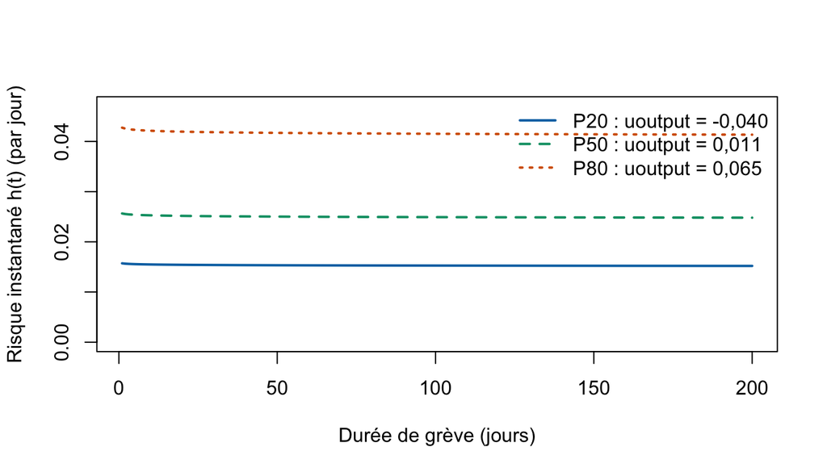

Risque instantané de fin de grève (par jour) prédit par le modèle de Weibull pour trois valeurs de uoutput (quantiles 20 %, 50 %, 80 %). Données StrikeDuration, censure à 200 jours.

```r
t_h <- seq(1, 200, by = 1)
haz <- sapply(1:3, function(k) {
  dweibull(t_h, shape = 1 / sigma_w, scale = exp(lp_w[k])) /
    pweibull(t_h, shape = 1 / sigma_w, scale = exp(lp_w[k]),
             lower.tail = FALSE)
})
matplot(t_h, haz, type = "l", col = cols_sc, lty = 1:3, lwd = 2,
        ylim = c(0, 1.1 * max(haz)),
        xlab = "Durée de grève (jours)",
        ylab = "Risque instantané h(t) (par jour)")
legend("topright",
       legend = paste0(c("P20", "P50", "P80"), " : uoutput = ",
                       fmt(sc$uoutput, 3)),
       col = cols_sc, lty = 1:3, lwd = 2, bty = "n")
```

Contrôle non paramétrique : si le risque est constant, le risque cumulé $\Lambda(t) = \lambda t$ est une droite. On compare le risque cumulé estimé (estimateur de Nelson–Aalen) à la droite d’un modèle exponentiel sans covariable.

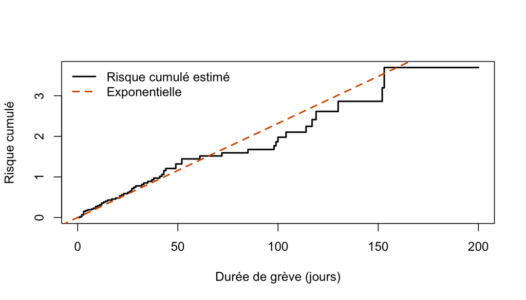

Risque cumulé estimé de toutes les grèves (escalier) et droite d’un modèle exponentiel sans covariable (tirets). Une droite indique un risque constant. Données StrikeDuration, censure à 200 jours.

```r
km_all <- survfit(S_strikes ~ 1, data = strikes)
expo_0 <- survreg(S_strikes ~ 1, data = strikes, dist = "exponential")

plot(km_all, fun = "cumhaz", conf.int = FALSE, lwd = 2,
     xlab = "Durée de grève (jours)", ylab = "Risque cumulé")
abline(a = 0, b = exp(-coef(expo_0)), col = "#D55E00", lty = 2, lwd = 2)
legend("topleft", legend = c("Risque cumulé estimé", "Exponentielle"),
       col = c("black", "#D55E00"), lty = c(1, 2), lwd = 2, bty = "n")
```

#### 11.3 Forme du risque dans le temps

- Le risque est **pratiquement constant** dans le temps. Avec $\hat p$ = 0,994 légèrement inférieur à 1, il décroît en théorie, mais de façon infime : entre le jour 1 et le jour 200, il est multiplié par $200^{\hat p - 1}$ = 0,97, et cet écart n’est pas significatif (p = 0,95). Le risque cumulé estimé suit d’ailleurs à peu près la droite de l’exponentielle jusqu’à 150 jours ; les sauts ultérieurs reposent sur les deux ou trois grèves encore en cours.
- Le **niveau** dépend de la conjoncture : au jour 30, le risque de fin vaut environ 0,015 par jour pour P20, 0,025 pour P50 et 0,042 pour P80. Les trois courbes sont proportionnelles : leur rapport (par exemple P80/P20 = 2,72) est le même à toutes les dates.
- Un risque de Weibull est proportionnel à $t^{p-1}$ : il croît ($p > 1$), décroît ($p < 1$) ou reste constant ($p = 1$, exponentielle, pratiquement notre cas). Il ne peut ni monter puis se stabiliser, ni monter puis redescendre. Pour un risque en cloche (qui monte puis redescend), on utiliserait une loi log-normale ou log-logistique, qui s’ajustent moins bien ici (Q10). Pour un risque qui monte puis se stabilise, il faudrait une loi gamma (forme > 1) ou un modèle exponentiel par morceaux.
- Lecture économique : il n’y a pas de **dépendance à la durée**. La chance qu’une grève se termine demain ne dépend pas, en moyenne, du temps depuis lequel elle dure. Prudence : une hétérogénéité non observée entre grèves tend à faire paraître le risque décroissant ; un risque plat agrégé n’exclut pas des risques individuels croissants.

### Q12 – Interprétation économique

#### 12.1 Quand les grèves ont-elles le plus de chances d’être courtes ?

En **conjoncture favorable** (choc d’activité positif et fort) :

- Kaplan–Meier, choc fort : durée médiane de 16,5 jours ; 35 % des grèves durent encore à 30 jours, 5 % à 60 jours ;
- Cox catégoriel : risque de fin 2,62 fois plus élevé qu’en choc faible (IC [1,38 ; 4,97]).

#### 12.2 Quand ont-elles le plus de chances d’être longues ?

En **conjoncture défavorable** (choc négatif, `Choc faible`) : durée médiane de 38 jours, 40 % des grèves encore en cours à 60 jours ; c’est aussi dans ce groupe que se trouve la seule grève de plus de 200 jours.

#### 12.3 Discussion

En termes de **rapports de risques instantanés** (modèle M1) :

- une amélioration de 0,01 du choc multiplie le taux instantané de fin de grève par 1,097 ; passer du premier au troisième quartile de `uoutput` le multiplie par 2,42 ;
- ce sont des rapports de **taux** : $h(t)$ n’est pas une probabilité, mais un taux de fin par jour parmi les grèves encore en cours. Il ne faut pas lire un HR de 2,4 comme « 2,4 fois plus de chances de finir la grève ».

En termes de **fonctions de survie** :

- la probabilité qu’une grève dure encore à 30 jours passe de 0,62 (P20) à 0,29 (P80) ; à 60 jours, de 0,38 à 0,08 ;
- de façon équivalente (Weibull), une hausse de 0,01 du choc raccourcit toutes les durées d’environ 9 %.

Mécanismes de **négociation salariale** et de **coûts de la grève** :

- Côté **employeur** : une grève coûte des ventes et des profits perdus. Quand la demande est forte de façon inattendue, chaque jour de production perdu coûte plus cher (commandes non honorées, clients perdus), et les stocks ne suffisent pas à les servir. L’employeur a donc intérêt à céder plus vite. En récession, la production perdue vaut peu (demande faible, stocks disponibles) : il peut attendre.
- Côté **grévistes** : la grève coûte des salaires perdus, et deux forces jouent en sens opposé en haut de cycle. De meilleures options extérieures (autres emplois) rendent l’attente moins coûteuse et poussent vers des grèves **plus longues**. Mais chaque jour de grève fait perdre davantage (heures supplémentaires, primes), ce qui pousse à conclure **plus vite**.
- Dans un modèle de négociation où le coût du retard pousse à l’accord, un coût conjoint de la grève plus élevé en haut de cycle conduit à des accords plus rapides. L’association nette observée suggère que ces forces dominent : la durée des grèves est **contracyclique**, ce qui est cohérent avec l’analyse de Kennan (1985), dont proviennent les données.

Limites :

- ce sont des **associations** : `uoutput` est un choc non anticipé, ce qui limite la causalité inverse, mais aucune autre caractéristique des grèves (secteur, taille, enjeux) n’est contrôlée ;
- l’échantillon est petit (62 grèves, 17 à 25 par classe) et `uoutput` a peu de valeurs distinctes : les effets sont estimés avec une précision limitée ;
- la censure à 200 jours est artificielle et ne touche qu’une grève : elle n’affecte pas les conclusions.